# Notebook

```python
import pandas as pd
import numpy as np
```

```python
import matplotlib.pyplot as plt
%matplotlib inline
import seaborn as sns
sns.set_style('whitegrid')
```

```python
from sklearn.preprocessing import StandardScaler
from sklearn.model_selection import train_test_split
from sklearn.metrics import confusion_matrix,accuracy_score,roc_curve,classification_report
from sklearn.linear_model import LogisticRegression
from sklearn.naive_bayes import GaussianNB
from xgboost import XGBClassifier
from sklearn.ensemble import RandomForestClassifier, ExtraTreesClassifier
from sklearn.tree import DecisionTreeClassifier
from sklearn.neighbors import KNeighborsClassifier
from sklearn.naive_bayes import GaussianNB
from sklearn.svm import SVC
```

```python
pip install mlxtend --upgrade --no-deps
```

```python
from mlxtend.classifier import StackingCVClassifier
```

```python
dt=pd.read_csv('heart.csv')
dt
```

|  | age | sex | cp | trestbps | chol | fbs | restecg | thalach | exang | oldpeak | slope | ca | thal | target |
| --- | --- | --- | --- | --- | --- | --- | --- | --- | --- | --- | --- | --- | --- | --- |
| 0 | 63 | 1 | 3 | 145 | 233 | 1 | 0 | 150 | 0 | 2.3 | 0 | 0 | 1 | 1 |
| 1 | 37 | 1 | 2 | 130 | 250 | 0 | 1 | 187 | 0 | 3.5 | 0 | 0 | 2 | 1 |
| 2 | 41 | 0 | 1 | 130 | 204 | 0 | 0 | 172 | 0 | 1.4 | 2 | 0 | 2 | 1 |
| 3 | 56 | 1 | 1 | 120 | 236 | 0 | 1 | 178 | 0 | 0.8 | 2 | 0 | 2 | 1 |
| 4 | 57 | 0 | 0 | 120 | 354 | 0 | 1 | 163 | 1 | 0.6 | 2 | 0 | 2 | 1 |
| ... | ... | ... | ... | ... | ... | ... | ... | ... | ... | ... | ... | ... | ... | ... |
| 298 | 57 | 0 | 0 | 140 | 241 | 0 | 1 | 123 | 1 | 0.2 | 1 | 0 | 3 | 0 |
| 299 | 45 | 1 | 3 | 110 | 264 | 0 | 1 | 132 | 0 | 1.2 | 1 | 0 | 3 | 0 |
| 300 | 68 | 1 | 0 | 144 | 193 | 1 | 1 | 141 | 0 | 3.4 | 1 | 2 | 3 | 0 |
| 301 | 57 | 1 | 0 | 130 | 131 | 0 | 1 | 115 | 1 | 1.2 | 1 | 1 | 3 | 0 |
| 302 | 57 | 0 | 1 | 130 | 236 | 0 | 0 | 174 | 0 | 0.0 | 1 | 1 | 2 | 0 |

303 rows × 14 columns

Notre dataset contient 303 bilan muni de 13 features et 1 variable target permettant de données chances d'un arrêt cardiaque.

```python
# On renomme nos features par le nom au complet

dt.columns = ['age', 'sex', 'chest_pain_type', 'resting_blood_pressure', 'cholesterol', 'fasting_blood_sugar', 'rest_ecg', 'max_heart_rate_achieved',
       'exercise_induced_angina', 'st_depression', 'st_slope','nb_vessels','thal','target']
```

```python
dt.info()
```

```
<class 'pandas.core.frame.DataFrame'>
RangeIndex: 303 entries, 0 to 302
Data columns (total 14 columns):
 #   Column                   Non-Null Count  Dtype
---  ------                   --------------  -----
 0   age                      303 non-null    int64
 1   sex                      303 non-null    int64
 2   chest_pain_type          303 non-null    int64
 3   resting_blood_pressure   303 non-null    int64
 4   cholesterol              303 non-null    int64
 5   fasting_blood_sugar      303 non-null    int64
 6   rest_ecg                 303 non-null    int64
 7   max_heart_rate_achieved  303 non-null    int64
 8   exercise_induced_angina  303 non-null    int64
 9   st_depression            303 non-null    float64
 10  st_slope                 303 non-null    int64
 11  nb_vessels               303 non-null    int64
 12  thal                     303 non-null    int64
 13  target                   303 non-null    int64
dtypes: float64(1), int64(13)
memory usage: 33.3 KB
```

Comme on peut le voir notre base de données ne contient aucune données manquantes ce qui est en soit bon signe pour la suite de l'étude.

N.B :notre base de données a été encodée par avance

```python
dt.describe()
```

|  | age | sex | chest_pain_type | resting_blood_pressure | cholesterol | fasting_blood_sugar | rest_ecg | max_heart_rate_achieved | exercise_induced_angina | st_depression | st_slope | nb_vessels | thal | target |
| --- | --- | --- | --- | --- | --- | --- | --- | --- | --- | --- | --- | --- | --- | --- |
| count | 303.000000 | 303.000000 | 303.000000 | 303.000000 | 303.000000 | 303.000000 | 303.000000 | 303.000000 | 303.000000 | 303.000000 | 303.000000 | 303.000000 | 303.000000 | 303.000000 |
| mean | 54.366337 | 0.683168 | 0.966997 | 131.623762 | 246.264026 | 0.148515 | 0.528053 | 149.646865 | 0.326733 | 1.039604 | 1.399340 | 0.729373 | 2.313531 | 0.544554 |
| std | 9.082101 | 0.466011 | 1.032052 | 17.538143 | 51.830751 | 0.356198 | 0.525860 | 22.905161 | 0.469794 | 1.161075 | 0.616226 | 1.022606 | 0.612277 | 0.498835 |
| min | 29.000000 | 0.000000 | 0.000000 | 94.000000 | 126.000000 | 0.000000 | 0.000000 | 71.000000 | 0.000000 | 0.000000 | 0.000000 | 0.000000 | 0.000000 | 0.000000 |
| 25% | 47.500000 | 0.000000 | 0.000000 | 120.000000 | 211.000000 | 0.000000 | 0.000000 | 133.500000 | 0.000000 | 0.000000 | 1.000000 | 0.000000 | 2.000000 | 0.000000 |
| 50% | 55.000000 | 1.000000 | 1.000000 | 130.000000 | 240.000000 | 0.000000 | 1.000000 | 153.000000 | 0.000000 | 0.800000 | 1.000000 | 0.000000 | 2.000000 | 1.000000 |
| 75% | 61.000000 | 1.000000 | 2.000000 | 140.000000 | 274.500000 | 0.000000 | 1.000000 | 166.000000 | 1.000000 | 1.600000 | 2.000000 | 1.000000 | 3.000000 | 1.000000 |
| max | 77.000000 | 1.000000 | 3.000000 | 200.000000 | 564.000000 | 1.000000 | 2.000000 | 202.000000 | 1.000000 | 6.200000 | 2.000000 | 4.000000 | 3.000000 | 1.000000 |

Regardons en premier la distribution statistiques de nos données

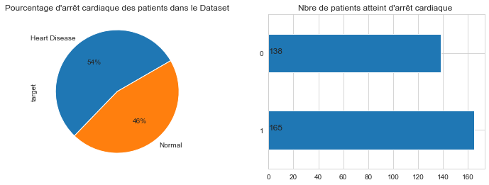

```python
fig, (ax1, ax2) = plt.subplots(nrows=1, ncols=2, sharey=False, figsize=(12,4))

#Pie Plot
ax1 = dt['target'].value_counts().plot.pie( x="Heart disease" ,y ='nbre.de patients',
                   autopct = "%1.0f%%",labels=["Heart Disease","Normal"], startangle = 30,ax=ax1);
ax1.set(title = "Pourcentage d'arrêt cardiaque des patients dans le Dataset")

#Countplot
ax2 = dt["target"].value_counts().plot(kind="barh" ,ax =ax2)

for i,j in enumerate(dt["target"].value_counts().values):
    ax2.text(.5,i,j,fontsize=12)
ax2.set(title = "Nbre de patients atteint d'arrêt cardiaque ")
plt.show()
```

notre dataset contient 46% des patients normal,et 54% des patient cardiaques

Passons maintenant à la distribution de nos données conditionnée par l'âge

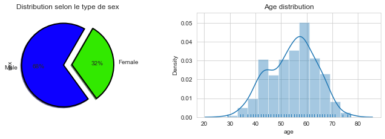

```python
plt.figure(figsize=(12,7))
plt.subplot(221)
dt["sex"].value_counts().plot.pie(autopct = "%1.0f%%",colors = sns.color_palette("prism",5),startangle = 60,labels=["Male","Female"],
wedgeprops={"linewidth":2,"edgecolor":"k"},explode=[.1,.1],shadow =True)
plt.title("Distribution selon le type de sex")
plt.subplot(222)
ax= sns.distplot(dt['age'], rug=True)
plt.title("Age distribution")
plt.show()
```

Dans ce qui va suivre on s'intéresse à séparer les patients normaux et les patients atteints d'antécendants cardiaques

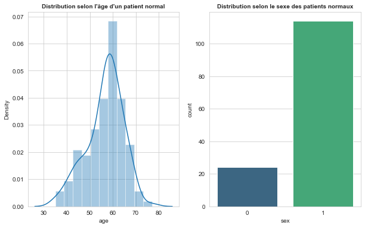

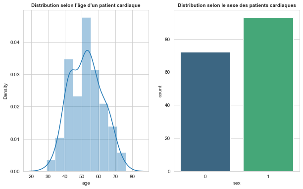

```python
target_1=dt[dt['target']==1]
target_0=dt[dt['target']==0]

#Partie Visualisation

#Voyons la distribution selon l'âge des "patients normaux"
fig=plt.figure(figsize=(10,6))

#Cas des patients normaux (target=0)
ax1=plt.subplot2grid((1,2),(0,0))
sns.distplot(target_0['age'])
plt.title("Distribution selon l'âge d'un patient normal",fontsize=10, weight='bold')

#Gender distribution pour les "patients normaux"
ax1=plt.subplot2grid((1,2),(0,1))
sns.countplot(target_0['sex'],palette='viridis')
plt.title("Distribution selon le sexe des patients normaux",fontsize=10,weight='bold')
plt.show()

#Distribution selon l'âge  pour les patients atteints d'arrêt cardiaque

fig=plt.figure(figsize=(10,6))
ax1=plt.subplot2grid((1,2),(0,0))
sns.distplot(target_1['age'])
plt.title("Distribution selon l'âge d'un patient cardiaque",fontsize=10, weight='bold')

#Gender distribution pour les patients cardiaques

ax1=plt.subplot2grid((1,2),(0,1))
sns.countplot(target_1['sex'],palette='viridis')
plt.title("Distribution selon le sexe des patients cardiaques",fontsize=10,weight='bold')
plt.show()
```

```python
def ord_plot(data,ordinal_feat):

    taget_0=data[data["target"]==0]
    taget_1=data[data["target"]==1]

    fig=plt.figure(figsize=(9,7))

    #Patients normaux
    print(f'----------------------{ordinal_feat}----------------------')
    ax=plt.subplot2grid((1,2),(0,0))
    sns.countplot(target_0[ordinal_feat],palette='viridis')
    plt.title('Effet rest ecg sur les patients normaux',fontsize=10,weight='bold')

    #patients Cardiaques
    print('\n')
    print('\n')
    ax=plt.subplot2grid((1,2),(0,1))
    sns.countplot(target_1[ordinal_feat],palette='viridis')
    plt.title('Effet du rest ecg sur les patients cardiaques',fontsize=10,weight='bold')
    plt.show()
    print("Regardons la différence de la distrubtion des classes plus explictement :")
    print('\n')
    plot_criteria=[ordinal_feat,'target']
    cm=sns.light_palette('red',as_cmap=True)
    ct=(round(pd.crosstab(data[plot_criteria[0]],data[plot_criteria[1]],normalize='columns') * 100,2)).style.background_gradient(cmap = cm)
    return(ct)
```

```python
#Initialisation de la liste contenant nos ordinal_features
ordinal_feat=['nb_vessels','rest_ecg','st_slope']
```

```
----------------------nb_vessels----------------------
```

[figure not shown]

```
Regardons la différence de la distrubtion des classes plus explictement :
```

| target nb_vessels | 0 | 1 |
| --- | --- | --- |
| 0 | 32.610000 | 78.790000 |
| 1 | 31.880000 | 12.730000 |
| 2 | 22.460000 | 4.240000 |
| 3 | 12.320000 | 1.820000 |
| 4 | 0.720000 | 2.420000 |

```python
ord_plot(dt,ordinal_feat[0])
```

```python
class expl_analysis:
    def __init__(self,dt):
        self.dt=dt

    #Pair_plot selon 'target'
    def pplot(self,num_vars):
        plt.figure(figsize=(7,4))
        sns.pairplot(self.dt,hue='target',vars=num_vars,corner=True)

    #Scatter_plot of the distribution selon 'target'
    def scatplot(self,X,Y):
        plt.figure(figsize=(7,4))
        sns.scatterplot(x=X,y=Y,hue='target',data=self.dt)

    #Plot pour detecter les outliers
    def outlier_plot(self,numeric_feat):
        plt.figure(figsize=(9,7))
        eda_hd=self.dt.reindex(columns = numeric_feat)
        for i in range(len(eda_hd.columns)):
            plt.subplot(3,3,i+1)
            sns.boxplot(eda_hd[eda_hd.columns[i]])
        plt.show()

    #Matrice de corrélation
    def eda_cor(self,numeric_feat):
        eda_hd=self.dt.reindex(columns = numeric_feat)
        eda_corr=eda_hd.corr()
        plt.figure(figsize=(7,4))
        sns.heatmap(eda_corr,annot=True,cmap='mako')
        plt.title('Matrice de Corrélation')
        plt.show()
```

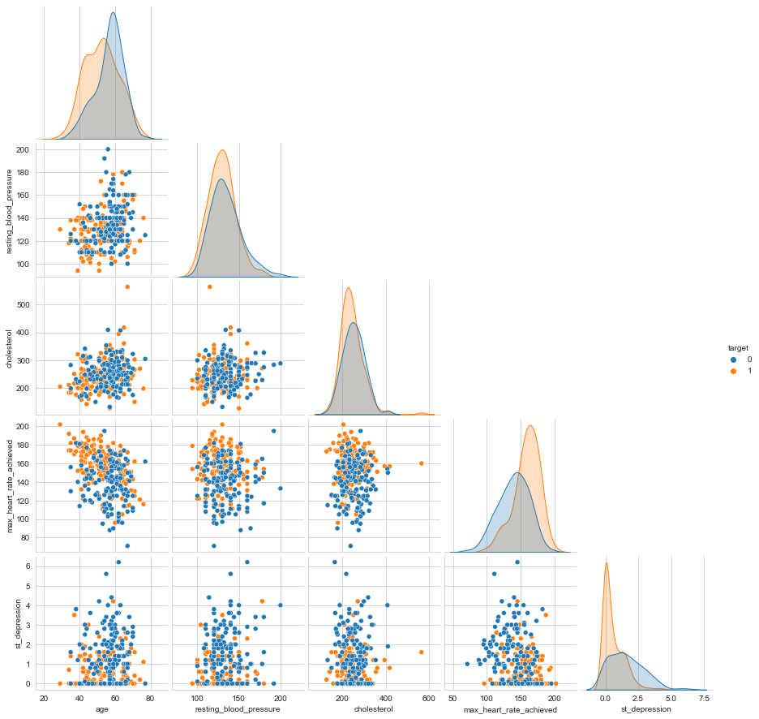

```python
# num_vars=["age","resting_blood_pressure","cholesterol"]
numeric_feat=["age","resting_blood_pressure","cholesterol",
                      "max_heart_rate_achieved","st_depression"]
#Initialisation de la classe
plot_data=expl_analysis(dt)

#Pair plot
plot_data.pplot(numeric_feat)
```

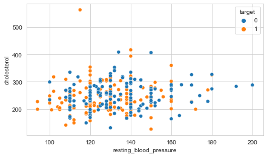

```python
#Relation visuelle entre resting_blood_pressure et cholesterol
X='resting_blood_pressure'
Y='cholesterol'
plot_data.scatplot(X,Y)
```

Comme on l'a cité avant on est belle est bien en présence de quelques outliers comme le montre le plot ci-dessus avec des valeurs assez dispersées.

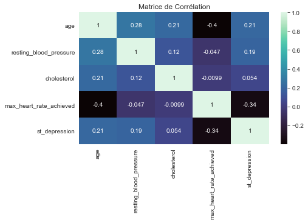

```python
plot_data.eda_cor(numeric_feat)
```

**Nettoyage de données**

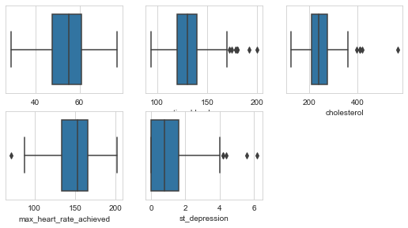

```python
numeric_feat=["age","resting_blood_pressure","cholesterol",
                      "max_heart_rate_achieved","st_depression"]
plot_data.outlier_plot(numeric_feat)
```

On remarque que notre base de données contient pas mal de outiliers

Passons maintenant à l'étape de suppression d'outliers, on commence par sélectionner les valeurs de type numériques

```python
data_numeric = dt[['resting_blood_pressure','cholesterol','max_heart_rate_achieved','st_depression']]
data_numeric.head()
```

|  | resting_blood_pressure | cholesterol | max_heart_rate_achieved | st_depression |
| --- | --- | --- | --- | --- |
| 0 | 145 | 233 | 150 | 2.3 |
| 1 | 130 | 250 | 187 | 3.5 |
| 2 | 130 | 204 | 172 | 1.4 |
| 3 | 120 | 236 | 178 | 0.8 |
| 4 | 120 | 354 | 163 | 0.6 |

Calculons le z-score donnée z=(x−u)/σ par afin d'effacer les outliers.

```python
import scipy as sp
z=np.abs(sp.stats.zscore(data_numeric))
print(z[:5])
```

```
[[0.76395577 0.25633371 0.01544279 1.08733806]
 [0.09273778 0.07219949 1.63347147 2.12257273]
 [0.09273778 0.81677269 0.97751389 0.31091206]
 [0.66386682 0.19835726 1.23989692 0.20670527]
 [0.66386682 2.08204965 0.58393935 0.37924438]]
```

Afin de mieux filter nos données on se fixe un seuil à ne pas dépasser pour limiter les dépassements de données

```python
threshold = 3
print(np.where(z > 3))
```

```
(array([ 28,  85, 204, 220, 221, 223, 246, 248, 272], dtype=int64), array([1, 1, 3, 1, 3, 0, 1, 0, 2], dtype=int64))
```

```python
dt_cl=dt[(z<3).all(axis=1)]
print(f"Taille des données avant traitement des outliers : {dt.shape}")
print(f"Taille des données après traitement des outliers :{dt_cl.shape}")
```

```
Taille des données avant traitement des outliers : (303, 14)
Taille des données après traitement des outliers :(294, 14)
```

```python
#Sauvegarde des données nettoyées
dt_cl.to_csv('dt_cl.csv', index=False)
```

##### Normalisation des variables numériques

```python
min_age=dt_cl['age'].min()
max_age=dt_cl['age'].max()
min_resting_blood_pressure=dt_cl['resting_blood_pressure'].min()
max_resting_blood_pressure=dt_cl['resting_blood_pressure'].max()
min_cholesterol=dt_cl['cholesterol'].min()
max_cholesterol=dt_cl['cholesterol'].max()
min_max_heart_rate_achieved=dt_cl['max_heart_rate_achieved'].min()
max_max_heart_rate_achieved=dt_cl['max_heart_rate_achieved'].max()
min_st_depression=dt_cl['st_depression'].min()
max_st_depression=dt_cl['st_depression'].max()
min_age, min_resting_blood_pressure, min_cholesterol, min_max_heart_rate_achieved, min_st_depression, max_age, max_resting_blood_pressure, max_cholesterol, max_max_heart_rate_achieved, max_st_depression,
```

```
(29, 94, 126, 88, 0.0, 77, 180, 394, 202, 4.4)
```

```python
dt_cl['age']=(dt_cl['age']-min_age)/(max_age-min_age)
dt_cl['resting_blood_pressure']=(dt_cl['resting_blood_pressure']-min_resting_blood_pressure)/(max_resting_blood_pressure-min_resting_blood_pressure)
dt_cl['cholesterol']=(dt_cl['cholesterol']-min_cholesterol)/(max_cholesterol-min_cholesterol)
dt_cl['max_heart_rate_achieved']=(dt_cl['max_heart_rate_achieved']-min_max_heart_rate_achieved)/(max_max_heart_rate_achieved-min_max_heart_rate_achieved)
dt_cl['st_depression']=(dt_cl['st_depression']-min_st_depression)/(max_st_depression-min_st_depression)
dt_cl.head()
```

|  | age | sex | chest_pain_type | resting_blood_pressure | cholesterol | fasting_blood_sugar | rest_ecg | max_heart_rate_achieved | exercise_induced_angina | st_depression | st_slope | nb_vessels | thal | target |
| --- | --- | --- | --- | --- | --- | --- | --- | --- | --- | --- | --- | --- | --- | --- |
| 0 | 0.708333 | 1 | 3 | 0.593023 | 0.399254 | 1 | 0 | 0.543860 | 0 | 0.522727 | 0 | 0 | 1 | 1 |
| 1 | 0.166667 | 1 | 2 | 0.418605 | 0.462687 | 0 | 1 | 0.868421 | 0 | 0.795455 | 0 | 0 | 2 | 1 |
| 2 | 0.250000 | 0 | 1 | 0.418605 | 0.291045 | 0 | 0 | 0.736842 | 0 | 0.318182 | 2 | 0 | 2 | 1 |
| 3 | 0.562500 | 1 | 1 | 0.302326 | 0.410448 | 0 | 1 | 0.789474 | 0 | 0.181818 | 2 | 0 | 2 | 1 |
| 4 | 0.583333 | 0 | 0 | 0.302326 | 0.850746 | 0 | 1 | 0.657895 | 1 | 0.136364 | 2 | 0 | 2 | 1 |

Notre base est prét pour la modélisation

### Modélisation

#### Diviser la base en un ensemble d'apprentissage et un ensemble de test

```python
X = dt_cl.drop('target', axis=1)
Y = dt_cl['target']
Y
```

```
0      1
1      1
2      1
3      1
4      1
      ..
298    0
299    0
300    0
301    0
302    0
Name: target, Length: 294, dtype: int64
```

```python
X_train, X_test, Y_train, Y_test=train_test_split(X,Y,test_size =0.2,random_state=0)
X_train.shape , Y_train.shape, X_test.shape, Y_test.shape
```

```
((235, 13), (235,), (59, 13), (59,))
```

```python
print('la distribution de la variable target dans le train set :')
print(Y_train.value_counts())
print('la distribution de la variable target dans le test set :')
print(Y_test.value_counts())
```

```
la distribution de la variable target dans le train set :
1    134
0    101
Name: target, dtype: int64
la distribution de la variable target dans le test set :
0    30
1    29
Name: target, dtype: int64
```

### Création des modèles de classification

### I- Forets Aléatoires

```python
#Parameter to be choosen

# Number of trees in random forest
n_estimators = [int(x) for x in np.linspace(start = 10, stop = 80, num = 10)]
# Number of features to consider at every split
max_features = ['auto', 'sqrt']
# Maximum number of levels in tree
max_depth = [2,4]
# Minimum number of samples required to split a node
min_samples_split = [2, 5]
# Minimum number of samples required at each leaf node
min_samples_leaf = [1, 2]
# Method of selecting samples for training each tree
bootstrap = [True, False]

# Create the param grid
param_grid = {'n_estimators': n_estimators,
               'max_features': max_features,
               'max_depth': max_depth,
               'min_samples_split': min_samples_split,
               'min_samples_leaf': min_samples_leaf,
               'bootstrap': bootstrap}
```

```python
from sklearn.model_selection import GridSearchCV
rf_Model=RandomForestClassifier()
rf_Grid = GridSearchCV(estimator = rf_Model, param_grid = param_grid, cv = 3, verbose=0, n_jobs = 4)
#Fitting the model on the training set
rf_Grid.fit(X_train,Y_train)
```

```
GridSearchCV(cv=3, estimator=RandomForestClassifier(), n_jobs=4,
             param_grid={'bootstrap': [True, False], 'max_depth': [2, 4],
                         'max_features': ['auto', 'sqrt'],
                         'min_samples_leaf': [1, 2],
                         'min_samples_split': [2, 5],
                         'n_estimators': [10, 17, 25, 33, 41, 48, 56, 64, 72,
                                          80]})
```

```python
#Slecting the best parameter and the predicting our target

print(rf_Grid.best_estimator_)
print('\n')
print('-'*70)
print('\n')
print(rf_Grid.best_params_)

#Let's advance to the prediction phase

rf_Grid.best_estimator_.fit(X_train,Y_train)
y_pred=rf_Grid.best_estimator_.predict(X_test)
print('\n')
print('-'*70)
print('\n')
print(f'{accuracy_score(Y_test,y_pred)*100}')
```

```
RandomForestClassifier(max_depth=2, min_samples_leaf=2, n_estimators=25)


----------------------------------------------------------------------


{'bootstrap': True, 'max_depth': 2, 'max_features': 'sqrt', 'min_samples_leaf': 2, 'min_samples_split': 2, 'n_estimators': 25}


----------------------------------------------------------------------


86.4406779661017
```

##### Notre modèle est precise presque à 87%

### II-Gradient de Boosting et autre Algorithmes

#### Ici nous testerons selon différents algorithme le modèle qui prédit au mieux nos classes

-K-Nearest Neighbour

-Logistic Regression

-Extra trees

-Support Vector Machine

-Random Forest Classifier

-Gradient Boost (XGBoost)

-Decision Tree

-Naive Bayes

```python
class classifieur:

    def __init__(self,estimators):
        self.algo=estimators
        self.best_estimateurs={}
    #Fitting the models before the prediction phase

    def fit(self,X_train,Y_train):
        for estim in self.algo:
            self.algo[estim]['mod'].fit(X_train,Y_train)
            pred=self.algo[estim]['mod'].score(X_train,Y_train)*100
            self.best_estimateurs[estim]={"score":pred}

#     Showing the score related to the training part in order to verify if there's any underfit case
    def score_train(self):
        for estim in self.algo:
            print(f'------{estim}--------')
            print(f"Le score obtenu pour {estim} sur le train set est : {self.best_estimateurs[estim]['score']}")


    #Prediction used on the test set for all our models
    def pred(self,X_train,Y_train,X_test,Y_test):
        pred={}
        for estim in self.algo:
            self.algo[estim]['mod'].fit(X_train,Y_train)
            pred[estim]=self.algo[estim]['mod'].predict(X_test)
        return(pred)

    #Score lié à la qualité de nos prédiction
    def show_score(self,Y_test,pred):
        conf_mat={}
        acc_score={}
        for estim in self.algo:
            print(f"--------------{estim}-------------------")
            conf_mat[estim]=confusion_matrix(Y_test,pred[estim])
            acc_score[estim]=accuracy_score(Y_test,pred[estim])
            print(f'En faisant appel à la matrice de confusion on a : \n {conf_mat[estim]}')
            print('\n')
            print(f'Le score de précision de {estim} est de :\n {acc_score[estim]*100}')
            print('\n')
            print('On présente le rapport de classification avec toutes les métriques liées au score prédictif')
            print(classification_report(Y_test,pred[estim]))
            print(f"*"*40)
            print("\n")
        return(acc_score)

    def roc_curve(self,pred):
        plt.figure(figsize=(10,5))
        for estim in pred.keys():
            fpr,tpr,threshold = roc_curve(Y_test,pred[estim])
            sns.set_style('whitegrid')
            plt.title('Reciver Operating Characterstic Curve')
            plt.plot(fpr,tpr,label=f'{estim}')
        plt.ylabel('True positive rate')
        plt.xlabel('False positive rate')
        plt.legend()
        plt.show()

    def model_eval(self,acc_score):
        accuracy=acc_score.copy()
        accuracy.update((x,y*100) for x,y in acc_score.items())
        models=list(acc_score.keys())
        scores=list(accuracy.values())
        mod_ev=pd.DataFrame({'Model':models,'Accuracy':scores})
        mod_ev
        return(mod_ev)

# Estimators to be called
estimators={"knn":{'mod':KNeighborsClassifier(),"param":0},
                 "logistique regression":{'mod':LogisticRegression(),'param':0},
           "extra trees":{'mod':ExtraTreesClassifier(criterion = 'entropy',n_estimators=120, random_state=0,max_depth=7),"param":0},
           "svm":{"mod":SVC(kernel='rbf', C=2),"param":0},
             "random forest":{'mod':RandomForestClassifier(max_depth=4, min_samples_split=5, n_estimators=33),"param":0},
            "xgb":{'mod':XGBClassifier(learning_rate=0.01, n_estimators=25, max_depth=15,gamma=0.6, subsample=0.52,colsample_bytree=0.6,seed=27,
                    reg_lambda=2, booster='dart', colsample_bylevel=0.6, colsample_bynode=0.5),'param':0},

           "decision trees":{"mod":DecisionTreeClassifier(criterion = 'entropy',random_state=0,max_depth = 6),"param":0},
                 'naive bayes':{"mod":GaussianNB(),"param":0}}
```

[output not shown]

```python
classification=classifieur(estimators)
pred=classification.pred(X_train,Y_train,X_test,Y_test)
acc_score=classification.show_score(Y_test,pred)
```

[output not shown]

Résumons dans ce qui va suivre les résultats prédictifs obtenus

```python
model_ev=classification.model_eval(acc_score)
model_ev
```

[output not shown]

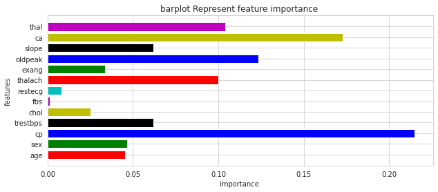

```python
imp_feature = pd.DataFrame({'Feature': ['age', 'sex', 'cp', 'trestbps', 'chol', 'fbs', 'restecg', 'thalach',
       'exang', 'oldpeak', 'slope', 'ca', 'thal'], 'Importance': estimators['random forest']['mod'].feature_importances_})
plt.figure(figsize=(10,4))
plt.title("barplot Represent feature importance ")
plt.xlabel("importance ")
plt.ylabel("features")
plt.barh(imp_feature['Feature'],imp_feature['Importance'],color = 'rgbkymc')
plt.show()
```

-La douleur thoracique, le nombre de vaisseaux principaux est un symptôme majeur de crise cardiaque.

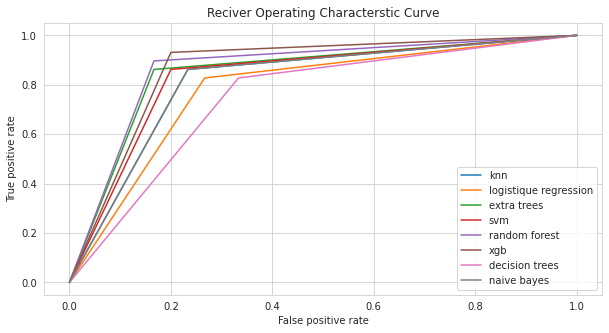

```python
classification.roc_curve(pred)
```

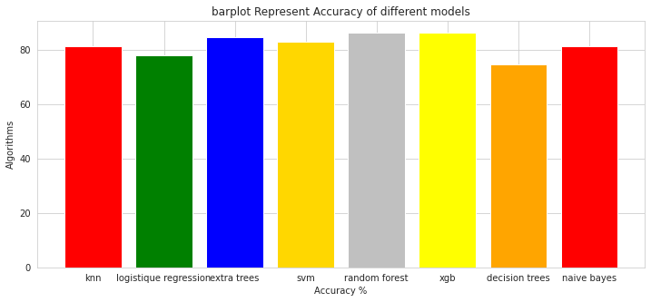

```python
colors = ['red','green','blue','gold','silver','yellow','orange',]
plt.figure(figsize=(12,5))
plt.title("barplot Represent Accuracy of different models")
plt.xlabel("Accuracy %")
plt.ylabel("Algorithms")
plt.bar(model_ev['Model'],model_ev['Accuracy'],color = colors)
plt.show()
```

### III-Le Staking

-on fait collaborer les différents modèles traités, Prenons dans ce cas nos trois meilleures modèles de prédiction qui sont :

-XGB

-Extra trees

-Random Forest

```python
xgb=estimators['xgb']['mod']
RandomForestClassifier=estimators['random forest']['mod']
ExtraTreesClassifier=estimators['extra trees']['mod']
```

```python
scv=StackingCVClassifier(classifiers=[xgb,RandomForestClassifier,ExtraTreesClassifier],meta_classifier= xgb,random_state=50)
scv.fit(X_train,Y_train)
scv_predicted = scv.predict(X_test)
scv_conf_matrix = confusion_matrix(Y_test, scv_predicted)
scv_acc_score = accuracy_score(Y_test, scv_predicted)
print("confussion matrix")
print(scv_conf_matrix)
print("\n")
print("Accuracy of StackingCVClassifier:",scv_acc_score*100,'\n')
print(classification_report(Y_test,scv_predicted))
```

```
confussion matrix
[[26  4]
 [ 3 26]]


Accuracy of StackingCVClassifier: 88.13559322033898

              precision    recall  f1-score   support

           0       0.90      0.87      0.88        30
           1       0.87      0.90      0.88        29

    accuracy                           0.88        59
   macro avg       0.88      0.88      0.88        59
weighted avg       0.88      0.88      0.88        59
```